# BBC Visual Journalism data team's cookbook for R graphics

Last updated: 2019-01-16

- I want to...
  - Create BBC style graphics
    - Load all the libraries you need
    - Install the bbplot package
    - How does the bbplot package work?
    - Save out your finished chart
  - Make a line chart
    - Simple line chart
    - Multiple line charts
  - Make a bar chart
  - Make a stacked bar chart
  - Make a grouped bar chart
  - Make a dumbbell chart
  - Make a histogram
  - Make changes to the legend
    - Remove the legend
    - Change the position of the legend
    - Remove the legend title
    - Reverse the order of your legend
    - Rearrange the layout of your legend
    - Change the appearance of your legend symbols
    - Add space between your legend labels
  - Make changes to the axes
    - Flip the coordinates of a plot
    - Add/remove gridlines
    - Change the axis text manually
    - Add thousand separators to your axis labels
    - Add percent symbol to your axis labels
    - Change the plot limits
    - Add axis titles
    - Modify axis titles
    - Add axis ticks
  - Add annotations
    - Add an annotation
    - Left-align/right-align text
    - Add labels based on your data
    - Add left-aligned labels to bar charts
    - Add a line
    - Add a curved line
    - Add an arrow
    - Add a line across the whole plot
  - Work with small multiples
    - Facets
    - Free scales
  - Do something else entirely
    - Increase or decrease margins
    - Exporting your plot and x-axis margins
    - Reorder bars by size
    - Reorder bars manually
    - Colour bars conditionally

# I want to...

## Create BBC style graphics

Some admin first up...

### Load all the libraries you need

A few of the steps in this cookbook - and to create charts in R in general - require certain packages to be installed and loaded. So that you do not have to install and load them one by one, you can use the `p_load` function in the `pacman` package to load them all at once with the following code.

```r
#This line of code installs the pacman page if you do not have it installed - if you do, it simply loads the package
if(!require(pacman))install.packages("pacman")

pacman::p_load('dplyr', 'tidyr', 'gapminder',
               'ggplot2',  'ggalt',
               'forcats', 'R.utils', 'png',
               'grid', 'ggpubr', 'scales',
               'bbplot')
```

### Install the bbplot package

The best and most efficient way to get set up to create BBC style graphics is to [follow the instructions in the bbplot package repository](https://github.com/bbc/bbplot).

When you have downloaded the package and successfully installed it you are good to go and create charts.

### How does the bbplot package work?

The package has two functions, `bbc_style()` and `finalise_plot()`.

`bbc_style()`: has no arguments and is added to the ggplot 'chain' after you have created a plot. What it does is generally makes text size, font and colour, axis lines, axis text, margins and many other standard chart components into BBC style, which has been formulated based on recommendations and feedback from the design team.

Note that colours for lines in the case of a line chart or bars for a bar chart, do not come out of the box from the `bbc_style()` function, but need to be explicitly set in your other standard `ggplot` chart functions.

The code below shows how the `bbc_style()` should be used within standard chart-production workflow. This is an example for a very simple line chart, using data from the `gapminder` package.

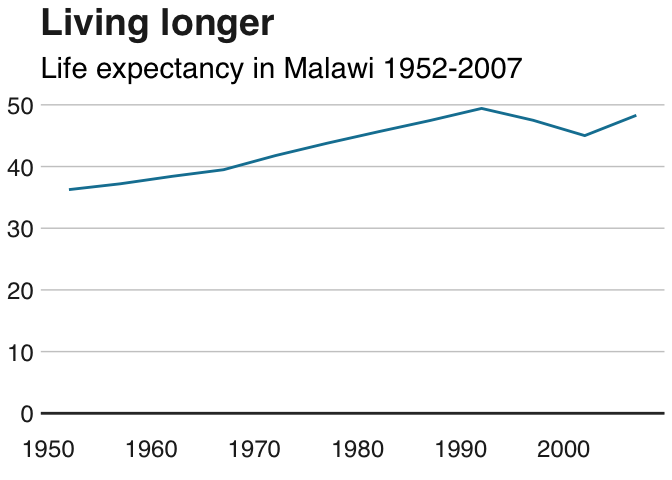

```r
#Data for chart from gapminder package
line_df <- gapminder %>%
  filter(country == "Malawi")

#Make plot
line <- ggplot(line_df, aes(x = year, y = lifeExp)) +
  geom_line(colour = "#1380A1", size = 1) +
  geom_hline(yintercept = 0, size = 1, colour="#333333") +
  bbc_style() +
  labs(title="Living longer",
       subtitle = "Life expectancy in Malawi 1952-2007")
```

Here is what the `bbc_style()` function actually does under the hood. It essentially modifies sets certain arguments in the `theme` function of `ggplot2`.

For example, the first argument is setting the font, size, typeface and colour of the title element of the plot.

```
## function() {
##   font <- "Helvetica"
##
##   ggplot2::theme(
##
##   #Text format:
##   #This sets the font, size, type and colour of text for the chart's title
##   plot.title = ggplot2::element_text(family=font,
##                             size=28,
##                             face="bold",
##                             color="#222222"),
##   #This sets the font, size, type and colour of text for the chart's subtitle, as well as setting a margin between the title and the subtitle
##   plot.subtitle = ggplot2::element_text(family=font,
##                                size=22,
##                                margin=ggplot2::margin(9,0,9,0)),
##   plot.caption = ggplot2::element_blank(),
##   #This leaves the caption text element empty, because it is set elsewhere in the finalise plot function
##
##   #Legend format
##   #This sets the position and alignment of the legend, removes a title and backround for it and sets the requirements for any text within the legend. The legend may often need some more manual tweaking when it comes to its exact position based on the plot coordinates.
##   legend.position = "top",
##   legend.text.align = 0,
##   legend.background = ggplot2::element_blank(),
##   legend.title = ggplot2::element_blank(),
##   legend.key = ggplot2::element_blank(),
##   legend.text = ggplot2::element_text(family=font,
##                              size=18,
##                              color="#222222"),
##
##   #Axis format
##   #This sets the text font, size and colour for the axis test, as well as setting the margins and removes lines and ticks. In some cases, axis lines and axis ticks are things we would want to have in the chart - the cookbook shows examples of how to do so.
##   axis.title = ggplot2::element_blank(),
##   axis.text = ggplot2::element_text(family=font,
##                            size=18,
##                            color="#222222"),
##   axis.text.x = ggplot2::element_text(margin=ggplot2::margin(5, b = 10)),
##   axis.ticks = ggplot2::element_blank(),
##   axis.line = ggplot2::element_blank(),
##
##   #Grid lines
##   #This removes all minor gridlines and adds major y gridlines. In many cases you will want to change this to remove y gridlines and add x gridlines. The cookbook shows you examples for doing so
##   panel.grid.minor = ggplot2::element_blank(),
##   panel.grid.major.y = ggplot2::element_line(color="#cbcbcb"),
##   panel.grid.major.x = ggplot2::element_blank(),
##
##   #Blank background
##   #This sets the panel background as blank, removing the standard grey ggplot background colour from the plot
##   panel.background = ggplot2::element_blank(),
##
##   #Strip background (#This sets the panel background for facet-wrapped plots to white, removing the standard grey ggplot background colour and sets the title size of the facet-wrap title to font size 22)
##   strip.background = ggplot2::element_rect(fill="white"),
##   strip.text = ggplot2::element_text(size  = 22,  hjust = 0)
##   )
##   }
## <environment: namespace:bbplot>
```

You can modify these settings for your chart, or add additional theme arguments, by calling the `theme` function with the arguments you want - but please note that for it to work you must call it *after* you have called the `bbc_style` function.

This will add some gridlines and are extra theme arguments to what is included in the `bbc_style()` function. There are many similar examples throughout the cookbook.

```r
theme(panel.grid.major.x = element_line(color="#cbcbcb"),
        panel.grid.major.y=element_blank())
```

### Save out your finished chart

Here are the function arguments: `finalise_plot(plot_name, source, save_filepath, width_pixels = 640, height_pixels = 450)`

- `plot_name`: the variable name that you have called your plot, for example for the chart example above `plot_name` would be `"line"`
- `source`: the source text that you want to appear at the bottom left corner of your plot. You will need to type the word `"Source:"` before it, so for example `source = "Source: ONS"` would be the right way to do that.
- `save_filepath`: the precise filepath that you want your graphic to save to, including the `.png` extension at the end. This does depend on your working directory and if you are in a specific R project. An example filepath would be: `Users/stylin02/bbc/r/vjdata.18529.nhs.ambulance.delays/output/charts/chart.png`.
- `width_pixels`: this is set to 640px by default, so only call this argument and specify the width you want your chart to be.
- `height_pixels`: this is set to 450px by default, so only call this argument and specify the height you want your chart to be.
- `logo_image_path`: the filepath to the logo image you would like to appear at the bottom right side of your plot, in the footer, which needs to be a PNG file. By default this is set to an empty background image that matches the colour of the plot background so it looks like there is nothing there, but you are able to change this and add your own image or logo if you wish.

Example of how the `finalise_plot()` is used in a standard workflow. This function is called once you have created and finalised your chart data, titles and added the `bbc_style()` to it:

```r
finalise_plot(plot_name = my_line_plot,
              source = "Gapminder",
              save_filepath = "filename_that_my_plot_should_be_saved_to-nc.png",
              width_pixels = 640,
              height_pixels = 550)
```

So once you have created your plot and are relatively happy with it, you can use the `finalise_plot()` function to make the final adjustments and save out your chart so that you can look at it outside RStudio.

It is important to mention that it is a good idea to do this early on because the position of the text and other elements do not render accurately in the RStudio Plots panel because this depends on the size and aspect ratio you want your plot to appea, so saving it out and opening up the files give you an accurate representation of how the graphic looks.

The finalise_plot() function does more than just save out your chart, it also left-aligns the title and subtitle as is standard for BBC graphics, adds a footer with the logo on the right side and lets you input source text on the left side.

```r
finalise_plot(plot_name = line,
              source = "Source: Gapminder",
              save_filepath = "images/line_plot_finalised_test.png",
              width_pixels = 640,
              height_pixels = 550)
```

## Make a line chart

### Simple line chart

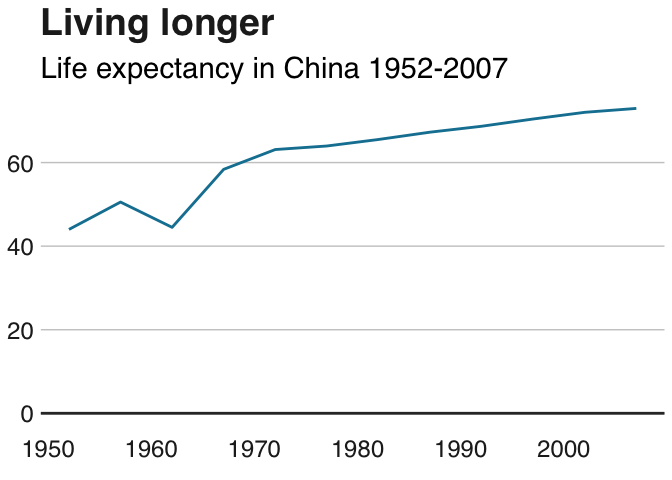

```r
#Prepare data
line_df <- gapminder %>%
  filter(country == "China")

#Make plot
line <- ggplot(line_df, aes(x = year, y = lifeExp)) +
  geom_line(colour = "#1380A1", size = 1) +
  geom_hline(yintercept = 0, size = 1, colour="#333333") +
  bbc_style() +
  labs(title="Living longer",
       subtitle = "Life expectancy in China 1952-2007")
```

### Multiple line charts

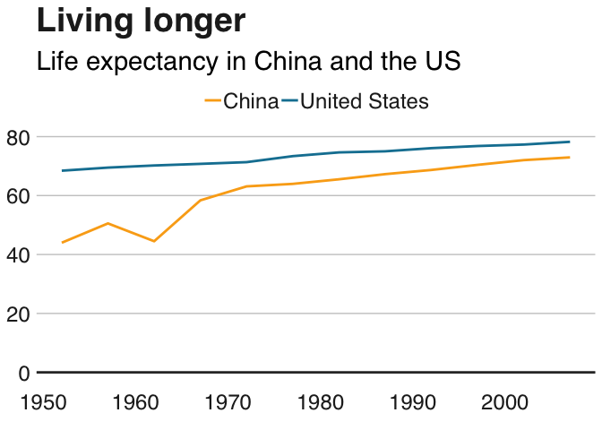

```r
#Prepare data
multiple_line_df <- gapminder %>%
  filter(country == "China" | country == "United States")

#Make plot
multiple_line <- ggplot(multiple_line_df, aes(x = year, y = lifeExp, colour = country)) +
  geom_line(size = 1) +
  geom_hline(yintercept = 0, size = 1, colour="#333333") +
  scale_colour_manual(values = c("#FAAB18", "#1380A1")) +
  bbc_style() +
  labs(title="Living longer",
       subtitle = "Life expectancy in China and the US")
```

## Make a bar chart

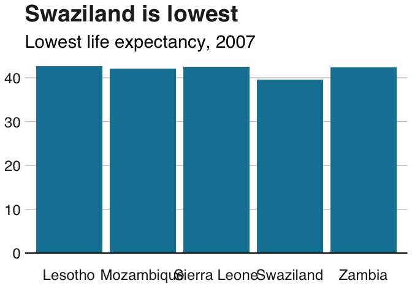

```r
#Prepare data
bar_df <- gapminder %>%
  filter(year == 2007) %>%
  arrange(lifeExp) %>%
  head(5)

#Make plot
bars <- ggplot(bar_df, aes(x = country, y = lifeExp)) +
  geom_bar(stat="identity",
           position="identity",
           fill="#1380A1") +
  geom_hline(yintercept = 0, size = 1, colour="#333333") +
  bbc_style() +
  labs(title="Swaziland is lowest",
       subtitle = "Lowest life expectancy, 2007")
```

## Make a stacked bar chart

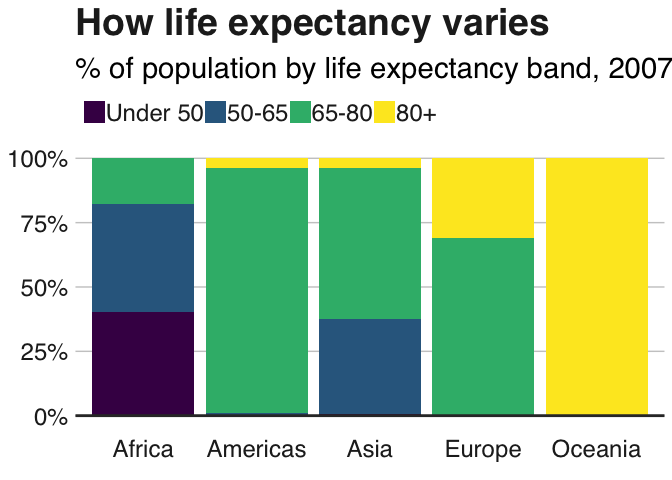

```r
#prepare data
stacked_df <- gapminder %>%
  filter(year == 2007) %>%
  mutate(lifeExpGrouped = cut(lifeExp,
                    breaks = c(0, 50, 65, 80, 90),
                    labels = c("Under 50", "50-65", "65-80", "80+"))) %>%
  group_by(continent, lifeExpGrouped) %>%
  summarise(continentPop = sum(as.numeric(pop)))

#set order of stacks by changing factor levels
stacked_df$lifeExpGrouped = factor(stacked_df$lifeExpGrouped, levels = rev(levels(stacked_df$lifeExpGrouped)))

#create plot
stacked_bars <- ggplot(data = stacked_df,
                       aes(x = continent,
                           y = continentPop,
                           fill = lifeExpGrouped)) +
  geom_bar(stat = "identity",
           position = "fill") +
  bbc_style() +
  scale_y_continuous(labels = scales::percent) +
  scale_fill_viridis_d(direction = -1) +
  geom_hline(yintercept = 0, size = 1, colour = "#333333") +
  labs(title = "How life expectancy varies",
       subtitle = "% of population by life expectancy band, 2007") +
  theme(legend.position = "top",
        legend.justification = "left") +
  guides(fill = guide_legend(reverse = TRUE))
```

This example shows proportions, but you might want to make a stacked bar chart showing number values instead - this is easy to change!

The value passed to the `position` argument will determine if your stacked chart shows proportions or actual values.

`position = "fill"` will draw your stacks as proportions, and `position = "identity"` will draw number values.

## Make a grouped bar chart

Making a grouped bar chart is very similar to making a bar chart.

You just need to change `position = "identity"` to `position = "dodge"`, and set the `fill` aesthetically instead:

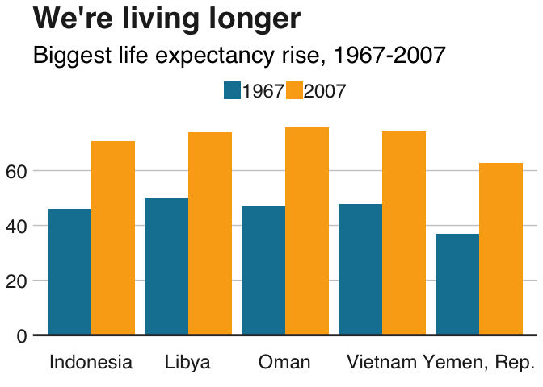

```r
#Prepare data
grouped_bar_df <- gapminder %>%
  filter(year == 1967 | year == 2007) %>%
  select(country, year, lifeExp) %>%
  spread(year, lifeExp) %>%
  mutate(gap = `2007` - `1967`) %>%
  arrange(desc(gap)) %>%
  head(5) %>%
  gather(key = year,
         value = lifeExp,
         -country,
         -gap)

#Make plot
grouped_bars <- ggplot(grouped_bar_df,
                       aes(x = country,
                           y = lifeExp,
                           fill = as.factor(year))) +
  geom_bar(stat="identity", position="dodge") +
  geom_hline(yintercept = 0, size = 1, colour="#333333") +
  bbc_style() +
  scale_fill_manual(values = c("#1380A1", "#FAAB18")) +
  labs(title="We're living longer",
       subtitle = "Biggest life expectancy rise, 1967-2007")
```

## Make a dumbbell chart

Another way of showing this data is a dumbbell chart:

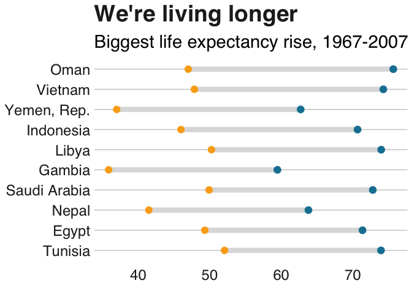

```r
library("ggalt")
library("tidyr")

#Prepare data
dumbbell_df <- gapminder %>%
  filter(year == 1967 | year == 2007) %>%
  select(country, year, lifeExp) %>%
  spread(year, lifeExp) %>%
  mutate(gap = `2007` - `1967`) %>%
  arrange(desc(gap)) %>%
  head(10)

#Make plot
ggplot(dumbbell_df, aes(x = `1967`, xend = `2007`, y = reorder(country, gap), group = country)) +
  geom_dumbbell(colour = "#dddddd",
                size = 3,
                colour_x = "#FAAB18",
                colour_xend = "#1380A1") +
  bbc_style() +
  labs(title="We're living longer",
       subtitle="Biggest life expectancy rise, 1967-2007")
```

## Make a histogram

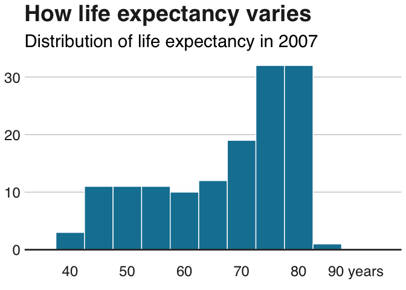

```r
hist_df <- gapminder %>%
  filter(year == 2007)

ggplot(hist_df, aes(lifeExp)) +
  geom_histogram(binwidth = 5, colour = "white", fill = "#1380A1") +
  geom_hline(yintercept = 0, size = 1, colour="#333333") +
  bbc_style() +
  scale_x_continuous(limits = c(35, 95),
                     breaks = seq(40, 90, by = 10),
                     labels = c("40", "50", "60", "70", "80", "90 years")) +
  labs(title = "How life expectancy varies",
       subtitle = "Distribution of life expectancy in 2007")
```

## Make changes to the legend

### Remove the legend

Remove the legend to become one - it's better to label data directly with text annotations.

Use `guides(colour=FALSE)` to remove the legend for a specific aesthetic (replace `colour` with the relevant aesthetic).

```r
multiple_line + guides(colour=FALSE)
```

You can also remove all legends in one go using `theme(legend.position = "none")`:

```r
multiple_line + theme(legend.position = "none")
```

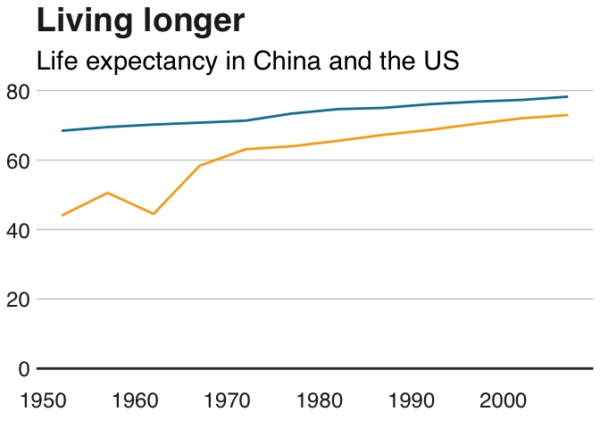

### Change the position of the legend

The legend's default position is at the top of your plot. Move it to the left, right or bottom outside the plot with:

```r
multiple_line + theme(legend.position = "right")
```

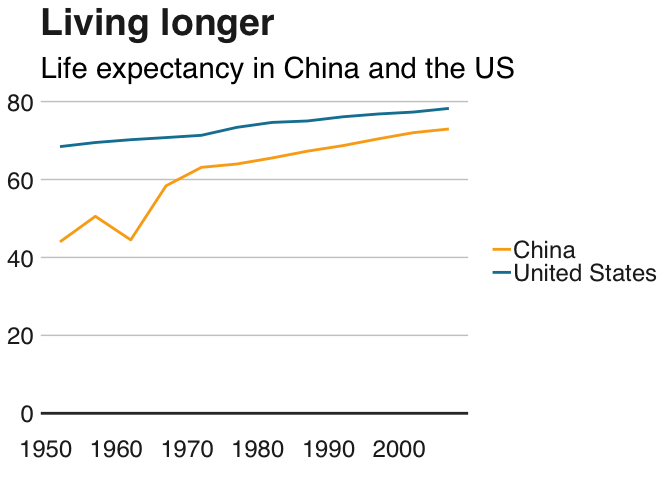

To be really precise about where we want our legend to go, instead of specifying "right" or "top" to change the general position of where the legend appears in our chart, we can give it specific coordinates.

For example `legend.position=c(0.98,0.1)` will move the legend to the bottom right. For reference, c(0,0) is bottom left, c(1,0) is bottom right, c(0,1) is top left and so on). Finding the exact position may involve some trial and error.

To check the exact position where the legend appears in your finalised plot you will have to check the file that is saved out after you run your `finalise_plot()` function, as the position will be relevant to the dimensions of the plot.

```r
  multiple_line + theme(legend.position = c(0.115,1.05),
                      legend.direction = "horizontal") +
  labs(title="Living longer",
       subtitle = "Life expectancy in China and the US\n")
```

To get the legend flush against the left side of your chart, it may be easier to set a negative left margin for the legend using `legend.margin`. The syntax is `margin(top, right, bottom, left)`.

You'll have to experiment to find the correct number to set the margin to for your chart - save it out with `finalise_plot()` and see how it looks.

```r
  + theme(legend.margin = margin(0, 0, 0, -200))
```

### Remove the legend title

Remove the legend title by tweaking your `theme()`. Don't forget that for any changes to the theme to work, they must be added after you've called `bbc_style()`!

```r
+ theme(legend.title = element_blank())
```

### Reverse the order of your legend

Sometimes you need to change the order of your legend for it to match the order of your bars. For this, you need `guides`:

```r
+ guides(fill = guide_legend(reverse = TRUE))
```

### Rearrange the layout of your legend

If you've got many values in your legend, you may need to rearrange the layout for aesthetic reasons.

You can specify the number of rows you want your legend to have as an argument to `guides`. The below code snippet, for instance, will create a legend with 4 rows:

```r
+ guides(fill = guide_legend(nrow = 4, byrow = T))
```

You may need to change `fill` in the code above to whatever aesthetic your legend is describing, e.g. `size`, `colour`, etc.

### Change the appearance of your legend symbols

You can override the default appearance of the legend symbols, without changing the way they appear in the plot, by adding the argument `override.aes` to `guides`.

The below will make the size of the legend symbols larger, for instance:

```r
+ guides(fill = guide_legend(override.aes = list(size = 4))))
```

### Add space between your legend labels

The default ggplot legend has almost no space between individual legend items. Not ideal.

You can add space by changing the scale labels manually.

For instance, if you have set the colour of your geoms to be dependent on your data, you will get a legend for the colour, and you can tweak the exact labels to get some extra space in by using the below snippet:

```r
+ scale_colour_manual(labels = function(x) paste0(" ", x, "  "))
```

If your legend is showing something different, you will need to change the code accordingly. For instance, for fill, you will need `scale_fill_manual()` instead.

## Make changes to the axes

### Flip the coordinates of a plot

Add `coord_flip()` to make your vertical bars horizontal:

```r
bars <- bars + coord_flip()
```

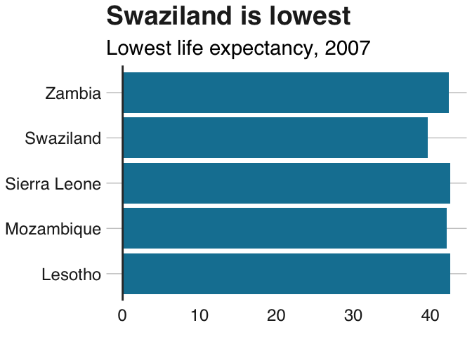

### Add/remove gridlines

The default theme only has gridlines for the y axis. Add x gridlines with `panel.grid.major.x = element_line`.

(Similarly, remove the gridlines on the y axis with `panel.grid.major.y=element_blank()`)

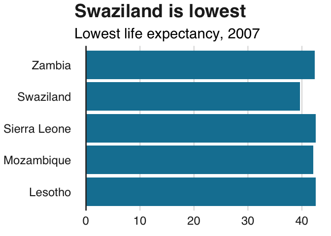

```r
bars <- bars + coord_flip() +
  theme(panel.grid.major.x = element_line(color="#cbcbcb"),
        panel.grid.major.y=element_blank())
```

### Change the axis text manually

The axis text of our bar chart looks weird. You can change the axis text labels freely with `scale_y_continuous` or `scale_x_continuous`:

```r
bars <- bars + scale_y_continuous(limits=c(0,45),
                   breaks = seq(0, 40, by = 10),
                   labels = c("0","10", "20", "30", "40 years"))

bars
```

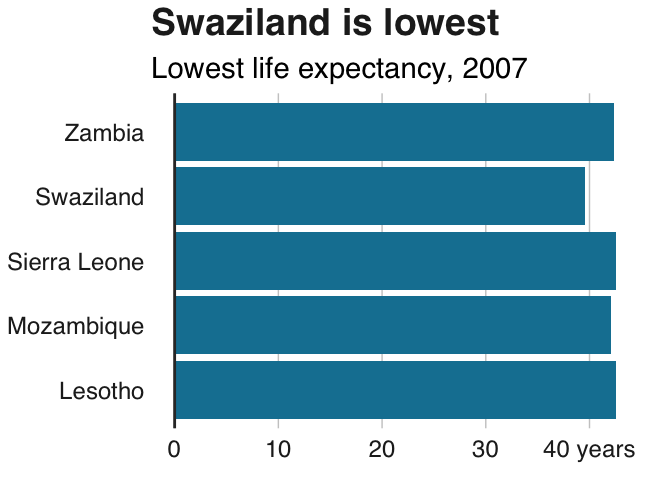

This will also specify the limits of your plot as well as where you want axis ticks.

### Add thousand separators to your axis labels

You can specify that you want your axis text to have thousand separators with an argument to `scale_y_continuous`.

There are two ways of doing this, one in base R which is a bit fiddly:

```r
+ scale_y_continuous(labels = function(x) format(x, big.mark = ",",
                                                 scientific = FALSE))
```

The second way relies on the `scales` package, but is much more concise:

```r
+ scale_y_continuous(labels = scales::comma)
```

### Add percent symbol to your axis labels

This is also easy to add with an argument to `scale_y_continuous`:

```r
+ scale_y_continuous(labels = function(x) paste0(x, "%"))
```

### Change the plot limits

The long way of setting the limits of your plot explicitly is with `scale_y_continuous` as above. But if you don't need to specify the breaks or labels the shorthand way of doing it is with `xlim` or `ylim`:

```r
bars + ylim(c(0,500))
```

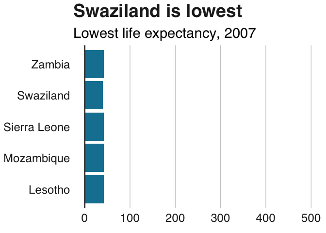

### Add axis titles

Our default theme has no axis titles, but you may wish to add them in manually. This is done by modifying `theme()` - note that you must do this after the call to `bbc_style()` or your changes will be overridden:

```r
+ theme(axis.title = element_text(size = 18))
```

### Modify axis titles

If you add in axis titles, they will by default be the column names in your dataset. You can change this to anything you want in your call to `labs()`.

For instance, if you wish your x axis title to be "I'm an axis" and your y axis label to be blank, this would be the format:

```r
+ labs(x = "I'm an axis",
       y = "")
```

### Add axis ticks

You can add axis tick marks by adding `axis.ticks.x` or `axis.ticks.y` to your `theme`:

```r
multiple_line + theme(
  axis.ticks.x = element_line(colour = "#333333"),
  axis.ticks.length =  unit(0.26, "cm"))
```

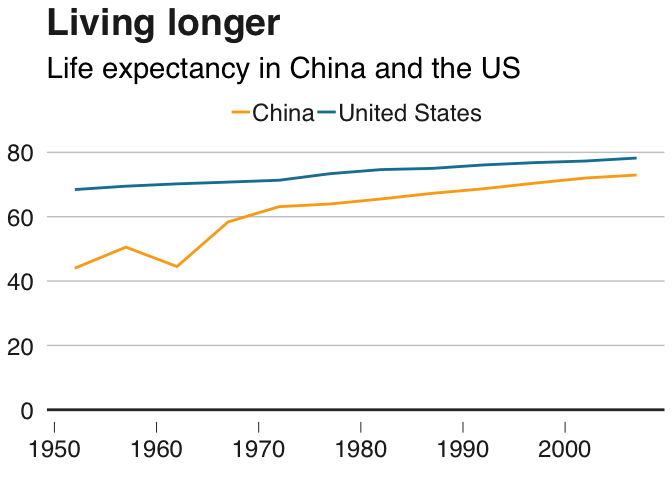

## Add annotations

### Add an annotation

The easiest way to add a text annotation to your plot is using `geom_label`:

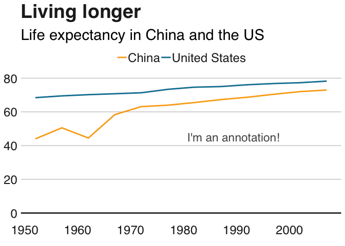

```r
multiple_line + geom_label(aes(x = 1980, y = 45, label = "I'm an annotation!"),
                           hjust = 0,
                           vjust = 0.5,
                           colour = "#555555",
                           fill = "white",
                           label.size = NA,
                           family="Helvetica",
                           size = 6)
```

The exact positioning of the annotation will depend on the `x` and `y` arguments (which is a bit fiddly!) and the text alignment, using `hjust` and `vjust` - but more on that below.

Add line breaks where necessary in your label with `\n`, and set the line height with `lineheight`.

```r
multiple_line <- multiple_line +
  geom_label(aes(x = 1980, y = 45, label = "I'm quite a long\nannotation over\nthree rows"),
             hjust = 0,
             vjust = 0.5,
             lineheight = 0.8,
             colour = "#555555",
             fill = "white",
             label.size = NA,
             family="Helvetica",
             size = 6)
```

Let's get our direct labels in there!

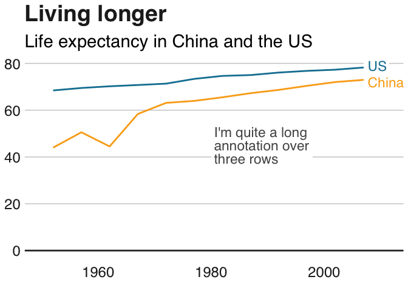

```r
multiple_line <- multiple_line +
  theme(legend.position = "none") +
  xlim(c(1950, 2011)) +
  geom_label(aes(x = 2007, y = 79, label = "US"),
             hjust = 0,
             vjust = 0.5,
             colour = "#1380A1",
             fill = "white",
             label.size = NA,
             family="Helvetica",
             size = 6) +
  geom_label(aes(x = 2007, y = 72, label = "China"),
             hjust = 0,
             vjust = 0.5,
             colour = "#FAAB18",
             fill = "white",
             label.size = NA,
             family="Helvetica",
             size = 6)
```

### Left-align/right-align text

The arguments `hjust` and `vjust` dictate horizontal and vertical text alignment. They can have a value between 0 and 1, where 0 is left-justified and 1 is right-justified (or bottom- and top-justified for vertical alignment).

### Add labels based on your data

The above method for adding annotations to your chart lets you specify the x and y coordinates exactly. This is very useful if we want to add a text annotation in a specific place, but would be very tedious to repeat.

Fortunately, if you want to add labels to all your data points, you can simply set the position based on your data instead.

Let's say we want to add data labels to our bar chart:

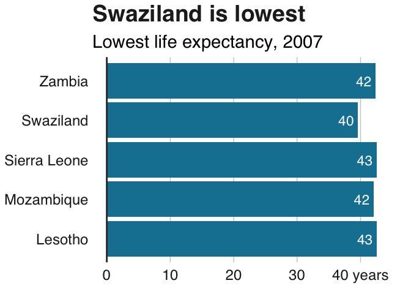

```r
labelled.bars <- bars +
  geom_label(aes(x = country, y = lifeExp, label = round(lifeExp, 0)),
             hjust = 1,
             vjust = 0.5,
             colour = "white",
             fill = NA,
             label.size = NA,
             family="Helvetica",
             size = 6)

labelled.bars
```

### Add left-aligned labels to bar charts

If you'd rather add left-aligned labels for your bars, just set the `x` argument based on your data, but specify the `y` argument directly instead, with a numeric value.

The exact value of `y` will depend on the range of your data.

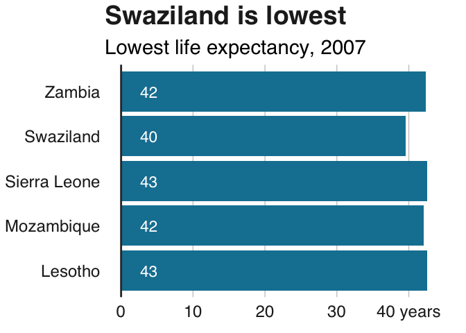

```r
labelled.bars.v2 <- bars +
  geom_label(aes(x = country,
                 y = 2,
                 label = round(lifeExp, 0)),
             hjust = 0,
             vjust = 0.5,
             colour = "white",
             fill = NA,
             label.size = NA,
             family="Helvetica",
             size = 6)

labelled.bars.v2
```

### Add a line

Add a line with `geom_segment`:

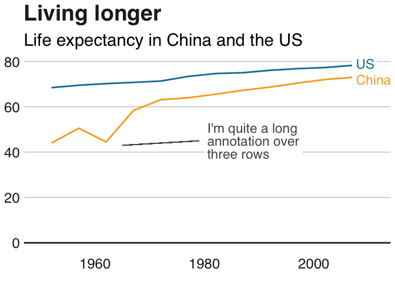

```r
multiple_line + geom_segment(aes(x = 1979, y = 45, xend = 1965, yend = 43),
                             colour = "#555555",
                             size=0.5)
```

The `size` argument specifies the thickness of the line.

### Add a curved line

For a curved line, use `geom_curve` instead of `geom_segment`:

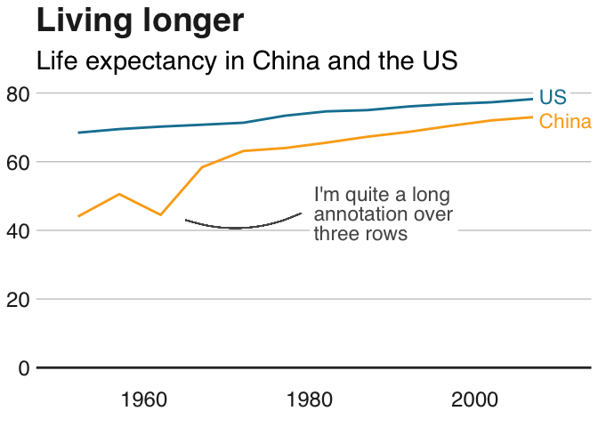

```r
multiple_line + geom_curve(aes(x = 1979, y = 45, xend = 1965, yend = 43),
                           colour = "#555555",
                           curvature = -0.2,
                           size=0.5)
```

The `curvature` argument sets the amount of curve: 0 is a straight line, negative values give a left-hand curve and positive values give a right-hand curve.

### Add an arrow

Turning a line into an arrow is fairly straightforward: just add the `arrow` argument to your `geom_segment` or `geom_curve`:

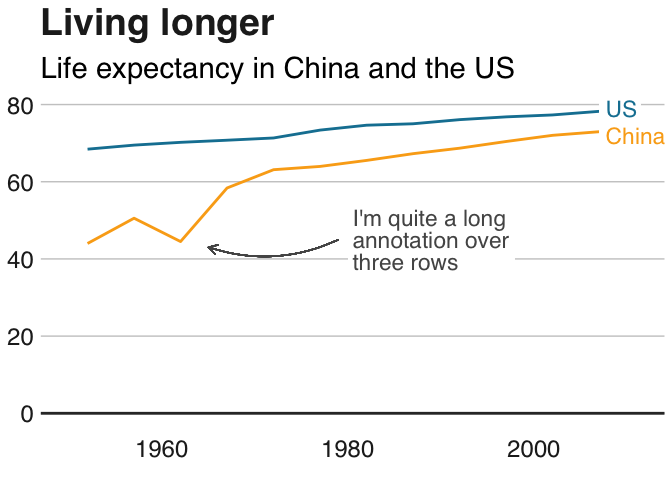

```r
multiple_line + geom_curve(aes(x = 1979, y = 45, xend = 1965, yend = 43),
                             colour = "#555555",
                             size=0.5,
                             curvature = -0.2,
                             arrow = arrow(length = unit(0.03, "npc")))
```

The first argument to `unit` sets the size of the arrowhead.

### Add a line across the whole plot

The easiest way to add a line across the whole plot is with `geom_vline()`, for a vertical line, or `geom_hline()`, for a horizontal one.

Optional additional arguments allow you to specify the size, colour and type of line (the default option is a solid one).

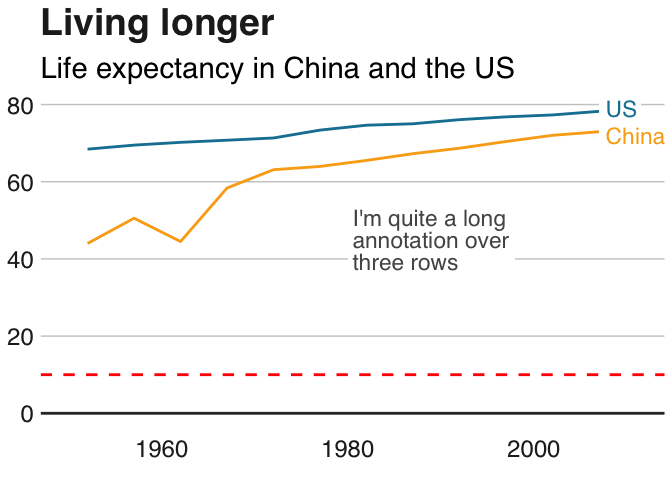

```r
multiple_line + geom_hline(yintercept = 10, size = 1, colour = "red", linetype = "dashed")
```

The line obviously doesn't add much in this example, but this is useful if you want to highlight something, e.g. a threshold level, or an average value.

It's also especially useful because our design style - as you may already have noticed from the charts on this page - is to add a vertical or horizontal baseline to our charts. This is the code to use:

```r
+ geom_hline(yintercept = 0, size = 1, colour = "#333333")
```

## Work with small multiples

Small multiple charts are easy to create with ggplot: it's called faceting.

### Facets

If you have data that you want to visualise split up by some variable, you need to use `facet_wrap` or `facet_grid`.

Add the variable you want to divide by to this line of code: `facet_wrap( ~ variable)`.

An additional argument to facet wrap, `ncol`, allows you to specify the number of columns:

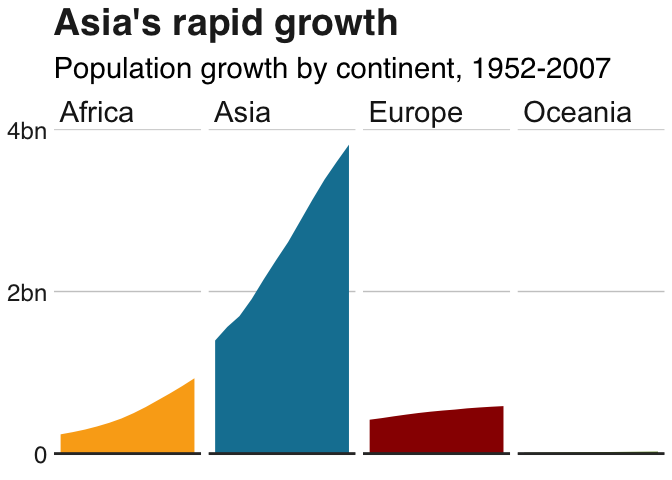

```r
#Prepare data
facet <- gapminder %>%
  filter(continent != "Americas") %>%
  group_by(continent, year) %>%
  summarise(pop = sum(as.numeric(pop)))

#Make plot
facet_plot <- ggplot() +
  geom_area(data = facet, aes(x = year, y = pop, fill = continent)) +
  scale_fill_manual(values = c("#FAAB18", "#1380A1","#990000", "#588300")) +
  facet_wrap( ~ continent, ncol = 5) +
  scale_y_continuous(breaks = c(0, 2000000000, 4000000000),
                     labels = c(0, "2bn", "4bn")) +
  bbc_style() +
  geom_hline(yintercept = 0, size = 1, colour = "#333333") +
  theme(legend.position = "none",
        axis.text.x = element_blank()) +
  labs(title = "Asia's rapid growth",
       subtitle = "Population growth by continent, 1952-2007")
```

### Free scales

You may have noticed in the chart above that Oceania, with its relatively small population, has disappeared completely.

By default, faceting uses fixed axis scales across the small multiples. It's always best to use the same y axis scale across small multiples, to avoid misleading, but sometimes you may need to set these independently for each multiple, which we can do by adding the argument `scales = "free"`.

If you just want to free the scales for one axis set the argument to `free_x` or `free_y`.

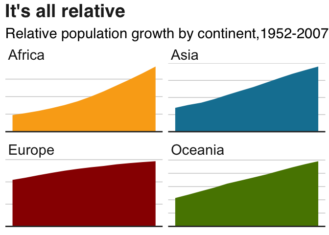

```r
#Make plot
facet_plot_free <- ggplot() +
  geom_area(data = facet, aes(x = year, y = pop, fill = continent)) +
  facet_wrap(~ continent, scales = "free") +
  bbc_style() +
  scale_fill_manual(values = c("#FAAB18", "#1380A1","#990000", "#588300")) +
  geom_hline(yintercept = 0, size = 1, colour = "#333333") +
  theme(legend.position = "none",
        axis.text.x = element_blank(),
        axis.text.y = element_blank()) +
  labs(title = "It's all relative",
       subtitle = "Relative population growth by continent,1952-2007")
```

## Do something else entirely

### Increase or decrease margins

You can change the margin around almost any element of your plot - the title, subtitles, legend - or the plot itself.

You shouldn't ordinarily need to change the default margins from the theme but if you do, the syntax is `theme(ELEMENT=element_text(margin=margin(0, 5, 10, 0)))`.

The numbers specify the top, right, bottom, and left margin respectively - but you can also specify directly which margin you want to change. For example, let's try giving the subtitle an extra-large bottom margin:

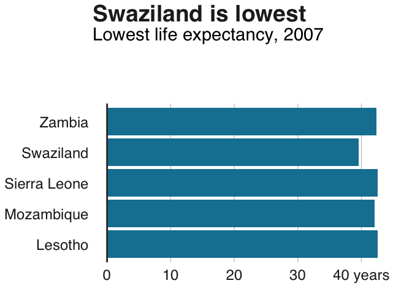

```r
bars + theme(plot.subtitle=element_text(margin=margin(b=75)))
```

Hm... maybe not.

### Exporting your plot and x-axis margins

You do need to think about your x-axis margin sizes when you are producing a plot that is beyond the default height in `bbplot`, which is 450px. This could be the case for example if you are creating a bar chart with lots of bars and want to make sure there is some breathing space between each bar and labels. If you do leave the margins as they are for plots with a greater height, then you could get a larger gap between the axis and your labels.

Here is a guide that we work to when it comes to the margins and the height of your bar chart (with coord_flip applied to it):

| size | t | b |
| --- | --- | --- |
| 550px | 5 | 10 |
| 650px | 7 | 10 |
| 750px | 10 | 10 |
| 850px | 14 | 10 |

So what you'd need to do is add this code to your chart if for example you wanted the height of your plot to be 650px instead of 450px.

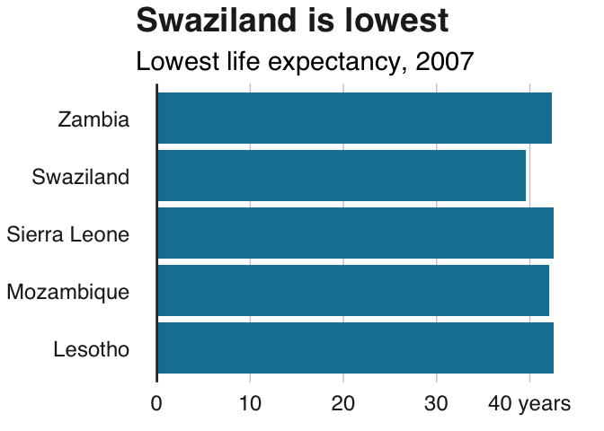

```r
bar_chart_tall <- bars + theme(axis.text.x = element_text(margin=margin(t = 7, b = 10)))
bar_chart_tall
```

Although it is much less likely, but if you do want to do the equivalent for a line chart and export it at a larger than default height, you need to do the same but change your values for t to negative values based on the table above.

### Reorder bars by size

By default, R will display your data in alphabetical order, but arranging it by size instead is simple: just wrap `reorder()` around the `x` or `y` variable you want to rearrange, and specify which variable you want to reorder it by.

E.g. `x = reorder(country, pop)`. Ascending order is the default, but you can change it to descending by wrapping `desc()` around the variable you're ordering by:

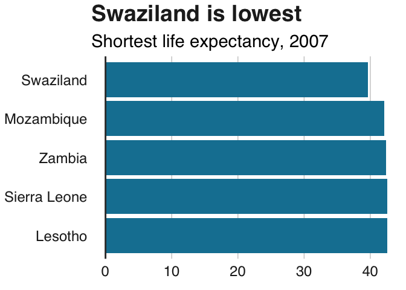

```r
bars <- ggplot(bar_df, aes(x = reorder(country, desc(lifeExp)), y = lifeExp)) +
  geom_bar(stat="identity", position="identity", fill="#1380A1") +
  geom_hline(yintercept = 0, size = 1, colour="#333333") +
  bbc_style() +
  coord_flip() +
  labs(title="Swaziland is lowest",
       subtitle = "Shortest life expectancy, 2007") +
  theme(panel.grid.major.x = element_line(color="#cbcbcb"),
        panel.grid.major.y=element_blank())
```

### Reorder bars manually

Sometimes you need to order your data in a way that isn't alphabetical or reordered by size.

To order these correctly you need to set your data's factor levels before making the plot.

Specify the order you want the categories to be plotted in the `levels` argument:

```r
dataset$column <- factor(dataset$column, levels = c("18-24","25-64","65+"))
```

You can also use this to reorder the stacks of a stacked bar chart.

### Colour bars conditionally

You can set aesthetic values like fill, alpha, size conditionally with `ifelse()`.

The syntax is `fill=ifelse(logical_condition, fill_if_true, fill_if_false)`.

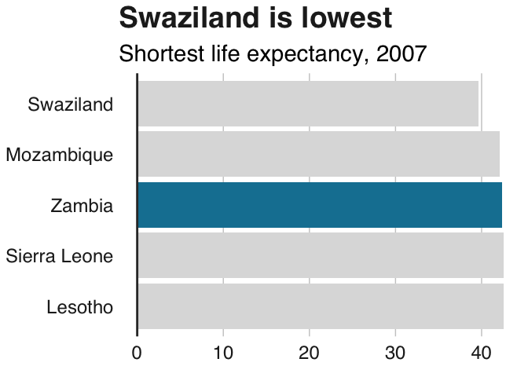

```r
ggplot(bar_df,
       aes(x = reorder(country, desc(lifeExp)), y = lifeExp)) +
  geom_bar(stat="identity", position="identity", fill=ifelse(bar_df$country == "Zambia", "#1380A1", "#dddddd")) +
  geom_hline(yintercept = 0, size = 1, colour="#333333") +
  bbc_style() +
  coord_flip() +
  labs(title="Swaziland is lowest",
       subtitle = "Shortest life expectancy, 2007") +
  theme(panel.grid.major.x = element_line(color="#cbcbcb"),
        panel.grid.major.y=element_blank())
```